# Tvyal Newsletter

Aghasi Tavadyan

2023-09-25

*English summary below.*

Հարգելի գործընկեր,

Հուսով եմ լավ եք այս անորոշության մեջ:

Արդեն 3-րդ ամիսն է ինչ ես Ձեզ ներկայացնում եմ այս տնտեսական վերլուծությունները։ Արդեն մոտ 1600 էլեկտրոնային փոսթ ստանում է շաբաթական այս վերլուծությունները։

Այս շաբաթ կորցրեցինք մեր ինքնության, արժանապատվության մի կարևոր հատված։

Ես երկար էմ մտածել ինչ վիճակագրական վերլուծություն կարելի է իրականացնել, որը արդիական կարող է լինել։ Հանգեցի նրան որ ինձ պետք է Ձեր օգնությունը՝ արժեք ստեղծելու համար։

Այս պահին արդիական է իրականացնել Հայաստանի մեդիադաշտի լայնածավալ վերլուծություն։ Սա իր մեջ նաև կներառի սենտիմենտալ վերլուծություն, այսինքն հնարավորություն կստանանք տեսնել թե խոշոր ԶԼՄ-ները ժամանակի ընթացքում ինչքան դրական կամ բացասական են վերաբերվել որոշ օրհասական բաներին։ Կկարողանանք տեսնել թե ժամանակի ընթացքում ինչպես են նրանք ազդում մեր հասարակության վրա։

Մտադրություն կա ուսումնասիրել 3 տիպի ԶԼՄ՝

- ներկա կառավարությանը սատարող ԶԼՄ-ներ (օրինակ՝ armtimes.com),
- ներկա կառավարությանը դեմ ԶԼՄ-ներ (օրինակ՝ 168.am/),
- և հնարավորինս անաչառ ԶԼՄ-ներ

Այս վերլուծությունը թույլ կտա տեսնել, թե ժամանակի ընթացքում այս ԶԼՄ-ները որոշակի կարևոր բառերի հանդեպ համեմադաբար ինչքան բացասական կամ դրական են վերաբերվել։ Այդ բառերի մեջ կարող են լինել “Արցախ”, “Հայաստան” և այլ բառերը (օրինակ՝ “Ռուսաստան”, “Ադրբեջան”, “Նիկոլ”, “Ֆրանսիա”, “ԱՄՆ”)։

Այս վերլուծության հիմքը դրված է դեռևս 2022թ․ սկզբին։ Երբ 2010 թվականից մինչև 2022 թվականը ներբեռնվել և ուսումնասիրվել են [Արմենպրեսի](https://armenpress.am/arm/) կողմից հրապարակված նյութերը։ Արդյունքը կարելի է տեսնել մեր կողմից մշակված [այս կայքեջում](https://tavad.shinyapps.io/armenpress/): Այս կայքը թույլ է տալիս հաշվել նորությունների վերնագրերում կիրառվող որոշակի բառերի քանակը և դրանց կիրառություն այլ չափանիշները: Կարող եք ընտրել մեկ կամ մի քանի բառ հաշվարկի համար, ինչպես նաև ժամանակահատվածը և վերլուծության եղանակը:

Հետազոտությունը իրականացվել է «Արմենպրես» լրատվական գործակալության կայքի նյութերի հիման վրա: Ստեղծվել է ծրագիր, որը 2010թ. սկսած բեռնել է այս կայքի բոլոր ինտերնետային հղումները, որոնց քանակը գերազանցել է կես միլիոնը (19Gb տեքստային տվյալ): Այնուհետև լուրերի հղումները մաքրվել են և ստեղծվել է տվյալների բազա, որը իր մեջ ներառում է լուրի տեղադրման ամսաթիվը, վայրը, հղումը, վերնագրի տեքստը և հոդվածի տեքստը: Ստացված տվյալների վրա կատարվել է հետազոտություն և ստեղծվել է տվյալ [ինտերակտիվ կայքը](https://tavad.shinyapps.io/armenpress/):

Օրինակ՝

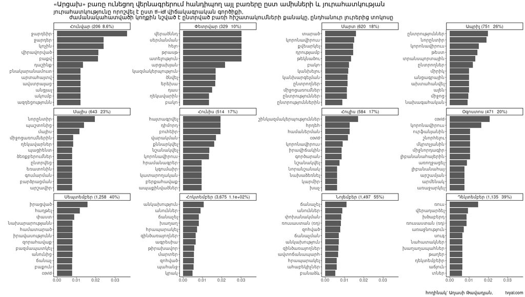

Վերլուծությունը շարունակելու համար պետք է Ձեր ֆինանսական և մտավոր աջակցությունը։ Խնդիրներից մեկը Հայոց լեզվի նորմալիզացման հարցն է, այսինքն յուրաքանչյուր բառ սկզբնական ձևի բերելը։ Սա պահանջում է հայերենի տրամաբանության լավ իմացություն։ Մյուսն այն է որ յուրաքանչյուր ԶԼՄ կայքէջ ունի իր տրամաբանությունը և դրա հետ աշխատելու բարդությունները։

Հուսով եմ ձեզանից ստանալ արձագանքներ։

## English Summary

In this weak & uncertain times I didn’t bother with English translation.

Այս վերլուծությունը առկա է նաև [մեր կայքեջում](https://www.tvyal.com/newsletter/2023_09_25), այս վերլուծության կոդը դրված է նաև [Github-ում](https://github.com/tavad/tvyal_newsletter)։

Եթե հնարավոր է, խնդրում եմ այս նյութը ուղարկել նաև այն մարդկանց, ում այն կարծում եք կարող է հետաքրքրել:

Սպասեք հաջորդ հաղորդագրությանը մի շաբաթվա ընթացքում:

Հարգանքներով,  
Աղասի Թավադյան  
25.09.2023  
[tvyal.com](https://www.tvyal.com/)  
[tavadyan.com](https://www.tavadyan.com/)

**Ուշադրություն. Ձեր էլ.փոստը մեյլիսթի մեջ է, որի միջոցով ես կիսվում եմ շաբաթական նյութեր, որոնք հիմնականում ներկայացնում են Հայաստանի տնտեսությանը: Նյութերը ներառում են գծապատկերներ, [տվյալների բազաներ](https://github.com/tavad/tvyal_newsletter), տեսանյութեր, հոդվածներ, [առցանց վահանակներ](https://www.tvyal.com/projects), տնտեսական գործիքներ, կանխատեսումներ և հաշվետվություններ: Եթե ցանկանում եք չեղարկել բաժանորդագրությունը, խնդրում եմ տեղեկացրեք ինձ, և ես կհեռացնեմ ձեր էլ. փոստը ցուցակից: Գրեք նաև եթե ունեք մենկնաբանություններ:**

**Important! Your email is part of the mailing list where I share weekly materials primarily focused on the Armenian economy. These materials encompass charts, [databases](https://github.com/tavad/tvyal_newsletter), videos, articles, [online dashboards](https://www.tvyal.com/projects), economic tools, forecasts, and reports. If you wish to unsubscribe, please let me know, and I will remove your email from the list. Please share your comments as well․**